# Statistical significance testing

- Show All Code
- Hide All Code
- View Source

Author

Thomas Bøjer Rasmussen

Published

2022-05-23

Notes on statistical significance testing

# 1 Primer

This section includes various definitions and theorems that are either implicitly or explicitly used throughout the notes.

## 1.1 Central limit theorem

The Central Limit Theorem (CLT) is a fundamental theorem in probability theory. It establishes, that even though independent draws from a distribution are not normal distribution, their properly normalized sum do tend towards a normal distribution. This allows us to construct test statistics where we know the (asymptotic) distribtion of the test statistic, making it easy to estimate *p*-values.

**Theorem 1 (Central Limit Theorem (CLT))** Let $X_1, X_2, \dots, X_n$ be a random sample from a distribution with mean $\mu$ and finite variance $\sigma^2$, and let $\hat{X}_n$ be the sample mean. Then

$$Z = \lim_{n \to \infty}\frac{\hat{X}_n - \mu}{\sigma / \sqrt{n}} \sim \mathcal{N}(0, 1)$$

# 2 Test statistics

## 2.1 What is a test statistic?

A test statistic is a numerical summary of a sample, $X_1, \dots, X_n$, that can be used to perform a hypothesis test. The test statistic is chosen/defined in such a way that its sampling distribution under the null hypothesis of interest is calculable, either exactly or approximately, so it can be used to calculate *p*-values.

Descriptive and test statistics share some qualities, but test statistics are specifically intended for use in statistical testing, whereas descriptive statistics are mainly used for interpretation. For example, continuous variables are often summarized as a median and interquartile intervals for descriptive purposes, but those statistics are not suitable for statistical testing since it is difficult to determine their distributions. On the other hand, the t-test statistic is an often use test statistic, but it is hard to interpret making it a less ideal descriptive statistic.

## 2.2 Example - One sample Z-test

Assume

Normal distributed data, unknown variance

$$X \sim N(\mu, \sigma^2),\ \ \ T = \frac{\hat{X} - \mu_0}{s / \sqrt{n}} \sim t(n-1)$$

Here the null hypothesis is usally chosen as $H_0: \mu_0 = 0$. This test statistic follows a Student’s $t$ distribution, a distribution that is calculable, ie we can easily calculate/estimate the CDF (needed for the p-value).

## 2.3 What is a *p*-value?

Let $t$ be an observed test statistic from an unknown distribution $T$. Then the *p*-value $p$ is the prior probability of observing a test-statistic value at as “extreme” as $t$ under the assumed null hypothesis $H_0$.

The *p*-value can also be viewed as the probability of obtaining an estimate at least as far from a specified values (eg the null value) as the estimate we have obtained, if the specified value were the true value. In other words, the *p*-value is a tail area probability based on the observed effect estimate; it is calculated as the probability of an effect estimate as large as or larger than the observed estimtae, assuming the null hypothesis is true.

Using our normal distribution example, we have that $T$ is symmetric around zero, so

$$p = P(|T| \geq |t| | H_0) = 2*F_{t(f)}(-|Z|)$$

The *p*-value is a function of the chosen test statistic, and is therefore a random variable. If the null hypothesis is true, and the underlying random variable is continuous then $p \sim U(0, 1)$ (Follow-up on this, should be easy to prove/understand why)

### 2.3.1 Example

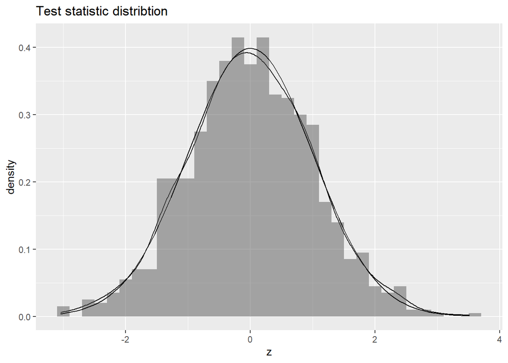

```r
# Simulate data from standard normal distribution
set.seed(1)
n_obs <- 1000
n_dat <- 1000

dat <- data.frame(
  x = rnorm(n_obs * n_dat),
  dataset = rep(1:n_dat, times = n_obs)
  ) %>%
  group_by(dataset) %>%
  summarize(z = (mean(x) - 0)/(sd(x)/sqrt(n_obs))) %>%
  mutate(p = 2*pt(-abs(z), df = n_obs - 1))

# z statistic should have standard normal distribution.
dat %>%
  ggplot(aes(x = z)) +
  geom_density() +
  geom_histogram(aes(y = ..density..), binwidth = 0.2, alpha = 0.5) +
  geom_function(fun = dnorm) +
  labs(title = "Test statistic distribtion")
```

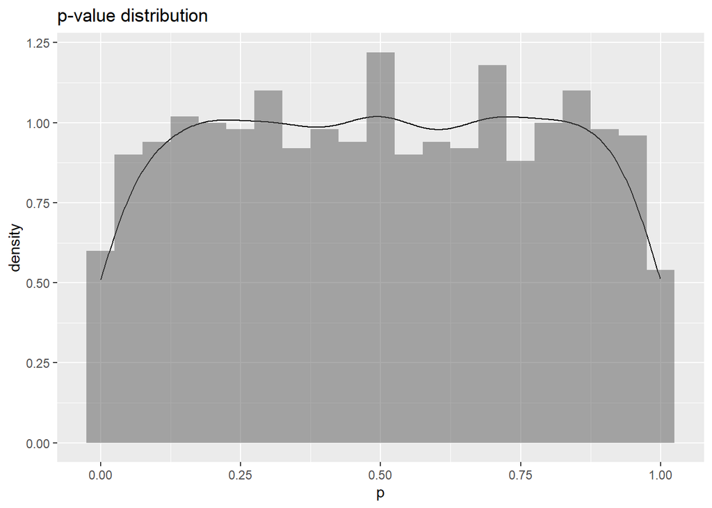

```r
# p-value should be uniformly distributed in [0;1]
dat %>%
  ggplot(aes(x = p)) +
  geom_density() +
  geom_histogram(aes(y = ..density..), binwidth = 0.05, alpha = 0.5) +
  labs(title = "p-value distribution")
```

```r
# p-value is prior probability of observing new test statistic at least as
# extreme as the observed one.

dat$p[1]
```

```
[1] 0.01093961
```

The t-statistic in the first sample is z = -2.5493906. The proportion of other t-statistics in the samples that are at least as extreme is 0.01001, and the p-value for the first sample is 0.0109396. These values are close to each other and would converge with larger amount of data.

## 2.4 Interpretation of the *p*-value

## 2.5 Problems with the *p*-value

Besides being hard to interpret correctly, the *p*-values is also sensitive to the sample size. Everything is “significant” if $n$ is large.

Take for example, a standard observational study with $n = 10000$, where we make a descriptive analysis, showing the proportion of a patient characteristic in each exposure group. Let’s say we want to include p-values testing whether or not the distribution of a dichotomous covariate is equal in each exposure group (not a good idea in the first place, separate discussion).

```r
set.seed(1)
n <- 10000
n_0 <- n/2
n_1 <- n/2
cov_0 <- rbinom(n_0, 1, 0.51)
cov_1 <- rbinom(n_1, 1, 0.49)
p_1 <- mean(cov_1)
p_0 <- mean(cov_0)
p <- (sum(cov_1) + sum(cov_0)) / (n_1 + n_0)
z <- (p_1 - p_0) / (sqrt(p*(1-p)*(1/n_1 + 1/n_0)))
p_val <- 2*pnorm(-abs(z))
p_val
```

```
[1] 0.003278804
```

We can see that even though the underlying distribution is basically identical the test concludes that the distribution is “significantly” different. This might be true in a mathematical sense, but in this context this is probably not the appropriate conclusion.

If $n$ is large, everything is significantly different. Not helpful.

## 2.6 Confidence intervals

For a given estimate, the 95% confidence interval is the set of all parameter values for which $p \geq 0.05$.

A common misinterpretation of the “coverage probability” of a CI is that is that given a CI then there is a $1-\alpha$ percent probility that the CI contains the true parameter. This is backwards. The coverage probability of a CI is that GIVEN the true paramter, an as yet unknown CI has a $1-\alpha$ probability of including the true value (given correct model assumptions). This is a variation of the incorrect interpretation of a p-value as a probability of there being a null-effect.

## 2.7 *p*-values in table 1’s

It is not uncommon to encounter so-called table 1’s presenting the distribution of patient characteristics in each exposure group, where *p*-values have been included to test the comparability of the distribution in each group.

In the case of a randomized controlled trial, this is completely senseless.<sup>1</sup> By design, we know that the means of the distributions are equal, and any departure from this is caused by chance. Testing whether any difference is caused by chance, is unreasonable, since the answer is always yes, regardless of the *p*-value. By design (using $\alpha = 0.05$), we would also expect significant *p*-values once for each 20 covariates on average.

The logic is the same in a propensity score matched or weighted cohort in an observational study.

For a traditional table 1 in an observational study, including *p*-values, also seem meaningless. The purpose of the analysis is descriptive: how does the population look like. There are (typically) no hypotheses about the distribution of covariates in the population of interest, and whether or not the distributions are “significantly” different has no relevance or impact on the study. It is the magnitude of imbalances between the group that is of interest, and the evaluation of this requires subject matter judgement, that can not be answered by statistical tests. A mean difference of 0.1 year of age in two treatment groups will be highly statistical significance in a significantly large population, but it is unlikely to be clinically relevant, and any regression/causal models in the study would likely include age, regardless of group distributions, *p*-values or whatever.

In the case of an observational study with the aim of simply describing a population, *p*-values still seem inappropriate. Large population: everything is significantly different. Evaluation still requires subject knowledge matter?

In any case, the *p*-value is a poor choice of statistic to evaluate whether or not there are distribution imbalances? In this case using standardized differences would be more appropriate?

```r
set.seed(1)
n <- 10**4
dat <- tibble(
  group = rbinom(n, 1, 0.5),
  age = rnorm(n, mean = 60 + group, sd = 10),
  biomarker = rnorm(n, mean = 1 + group, sd = 0.5)
)

tbl <- dat %>%
  tbl_summary(
    by = group,
    statistic = list(all_continuous() ~ "{mean} ({sd})"),
    digits = list(age ~ c(1, 1))
  ) %>%
  add_p()

tbl
```

| **Characteristic** | **0**, N = 5,047<sup>1</sup> | **1**, N = 4,953<sup>1</sup> | **p-value**<sup>2</sup> |
| --- | --- | --- | --- |
| age | 59.9 (9.9) | 60.8 (9.9) | <0.001 |
| biomarker | 1.00 (0.50) | 2.02 (0.50) | <0.001 |

<sup>1</sup> Mean (SD)  
<sup>2</sup> Wilcoxon rank sum test

As the example shows it does not take a big population to get small *p*-values. But is a mean difference of 1 year of age has any clinical revalence? Probably not. On the other hand, a difference of 1 unit of a biomarker might be enourmous and very important. Interpretation takes subject matter knowledge.

## 2.8 Compare parametric and non-parametric p-value

Assume two independent samples with unknown variances. We make no assumption of normal distributed populations, but we ensure that $n_1 + n_2 > 40$.

To test the hypothesis of equal means, we could either use Welch’s t-test or the Wilcox rank-sum test.

```r
set.seed(1)
n <- 10**3
n1 <- n/2
n2 <- n/2
x1 <- rnorm(n1)
x2 <- rnorm(n2, mean = 0.1)

d_0 <- 0
s12 = var(x1)
s22 = var(x2)

t = ((mean(x1) - mean(x2)) - d_0)/(sqrt(s12/n1 + s22/n2))
df = ((s12/n1 + s22/n2)**2) / ((s12/n1)**2/(n1 - 1) + (s22/n2)**2/(n2 - 1))


welch_pval <- 2*pt(-abs(t), df = df)
welch_pval
```

```
[1] 0.631341
```

```r
wilcox_pval <- wilcox.test(x1, x2)$p.value
wilcox_pval
```

```
[1] 0.5366737
```

Gives approximately the same answers, but the tests are not the same, so comparisons should be done with that in mind!

The Wilcoxon rank-sum test tests the hypothesis that the probability that a randomly drawn observation from one group is larger than a randomly drawn observation from the other is equal to 0.5 against an alternative hypothesis that the probability is not 0.5. In contrast, a t-test tests a null hypothesis of equal means in two groups against an alternative of unequal means. This is not the same.

```r
set.seed(1)
n <- 10**4
n1 <- n/2
n2 <- n/2
x1 <- rgamma(n1, shape = 5)
x2 <- rnorm(n2, mean = 5)

mean(x1)
```

```
[1] 5.020301
```

```r
mean(x2)
```

```
[1] 4.992744
```

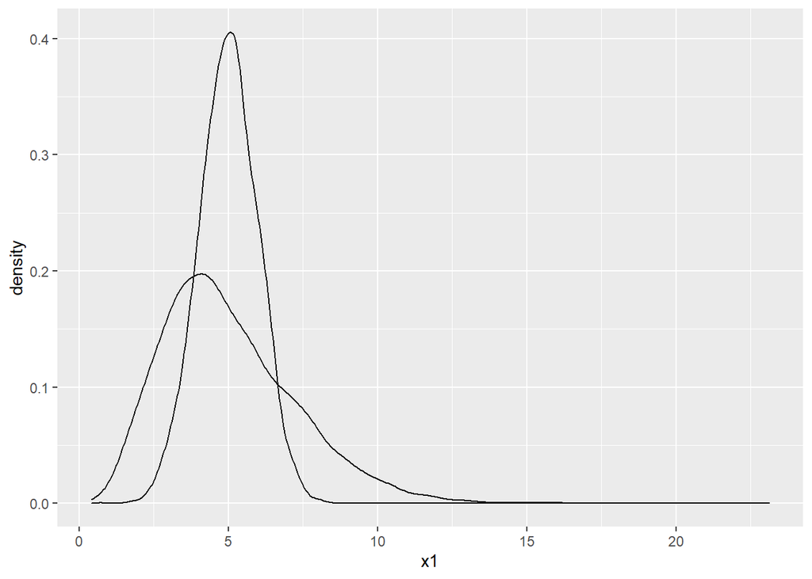

```r
ggplot() +
  geom_density(aes(x = x1)) +
  geom_density(aes(x = x2))
```

```r
d_0 <- 0
s12 = var(x1)
s22 = var(x2)

t = ((mean(x1) - mean(x2)) - d_0)/(sqrt(s12/n1 + s22/n2))
df = ((s12/n1 + s22/n2)**2) / ((s12/n1)**2/(n1 - 1) + (s22/n2)**2/(n2 - 1))


welch_pval <- 2*pt(-abs(t), df = df)
welch_pval
```

```
[1] 0.4257973
```

```r
wilcox_pval <- wilcox.test(x1, x2)$p.value
wilcox_pval
```

```
[1] 2.901544e-13
```

# 3 p-hacking

P-hacking, also called significance chasing, data-dredging, fishing etc, is the malpratice of finding patterns in the data that can be presented as statistical significant, thereby increasing the risk of false positives.

A common example is exploratory studies where results are cherry-picked for presentation based on the their p-value.

All data will have spurious associtations. Testing a hypothesis should be done with data that was not used to formulate the hypothesis. If p-hacking is done to find “interesting results”, that are then reported as if there was an a priori hypothesis, that will greatly increase the risk of false positives.

Any hypothesis discovered this way needs to be tested in a new sample.

# 4 Appendix

## References

1.

Stang A, Poole C, Kuss O. The ongoing tyranny of statistical significance testing in biomedical research. *European Journal of Epidemiology*. Published online 2010.

2.

Amrhein V, Greenland S, McShane B. Scientists rise up against statistical significance. *Nature*. Published online 2019.

3.

Wasserstein RL, Lazar NA. The ASA Statement on p-Values: Context, Process, and Purpose. *The American Statistician*. Published online 2016.

4.

Greenland S, Senn SJ, Rothman KJ, et al. Statistical tests, P values, confidence intervals, and power: A guide to misinterpretations. *European Journal of Epidemiology*. Published online 2016.

5.

Gelman A, Stern H. The Difference Between “Significant” and “Not Significant” is not Itself Statistically Significant. *The American Statistician*. Published online 2006.

6.

Demidenko E. The p-Value You Can’t Buy. *The American Statistician*. Published online 2016.

7.

Poole C. Low P-Values or Narrow Confidence Intervals: Which Are More Durable? *Epidemiology*. Published online 2001.

8.

Weinberg CR. It’s Time to Rehabilitate the P-Value. *Epidemiology*. Published online 2001.

9.

Nuzzo R. Scientific method: Statistical errors. *Nature*. Published online 2014.

10.

Ioannidis JPA. Why Most Published Research Findings Are False. *PLoS Medicine*. Published online 2005.

## Reuse

Creative Commons Zero v1.0 Universal